# Classifying Exercises Using Data from Wearable Accelerometers

Chris Selig

February 8, 2017

# Executive Summary

In this analysis, I will use a random forest model to predict which activities were performed based on belt, forearm, arm, and dumbell accelerometers.

# Data

The training data for this project are available here: https://d396qusza40orc.cloudfront.net/predmachlearn/pml-training.csv

The test data are available here: https://d396qusza40orc.cloudfront.net/predmachlearn/pml-testing.csv

```r
inTrain <- createDataPartition(y = training$classe, p = 0.7, list = FALSE)
training <- training[inTrain,]
validation <- training[-inTrain,]
```

# Exploratory Data Analysis

The training set has 160 variables and 13,737 observations. Another item of note is that there is a significant amount of missing values in some of the variables. As a matter of fact, over 13,000 for those variables. We will need to handle all of those missing values before we build a model.

```
## [1] 13737   160
```

A final takeaway from the exploratory analysis, is that there appears to be a row that is a summation line. These lines are tagged with “yes” in the new_window variable.

# Data Processing and Feature Selection

First up, I removed the summation lines from the training data.

```r
training <- training[!training$new_window == "yes",]
```

Looking at the training data set, there are variables that are useless, for example, time stamps and user names. I will remove those variables as well.

```r
training <- subset(training, select = -c(X, user_name, raw_timestamp_part_1,
                                         raw_timestamp_part_2, cvtd_timestamp, new_window))
```

At this point, there are still 154 variables in the training data set. Next, I will look for zero variance, or near zero variance variables. Near-zero variance means that the fraction of unique values over the sample size is low and the ratio of the frequency of the most prevalent value to the frequency of the second most prevalent value is large. So, near zero variances should have less predictive power. Here is the first 6 lines, which shows the variable kurtosis_roll_belt having zero variance.

```
##                    freqRatio percentUnique zeroVar   nzv
## num_window          1.037037      6.363501   FALSE FALSE
## roll_belt           1.102990      8.164632   FALSE FALSE
## pitch_belt          1.154472     12.526049   FALSE FALSE
## yaw_belt            1.080692     13.337303   FALSE FALSE
## total_accel_belt    1.064470      0.215838   FALSE FALSE
## kurtosis_roll_belt  0.000000      0.000000    TRUE  TRUE
```

After I remove the near zero variances, I am left with 54 variables in the training data set.

```
## [1] 13436    54
```

A lot of variables are still left. Next, I will use a random forest to see if I can elminate less important variables. During this process, I grew 250 trees and calculated their importance.

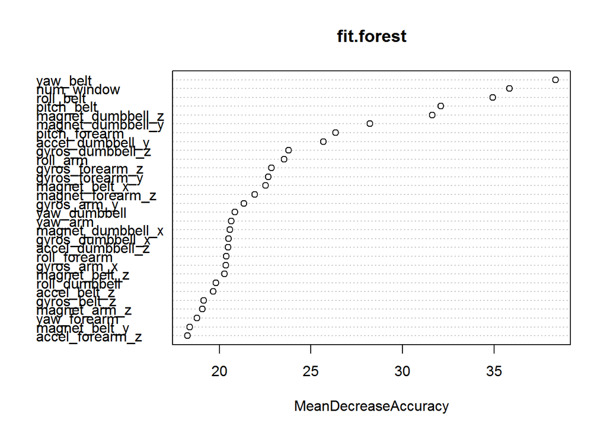

```r
fit.forest <- randomForest(classe ~., data = training, importance = TRUE, ntree = 250)
varImpPlot(fit.forest, type = 1)
```

# The Random Forest Model

The random forest model has been chosen to do the predictions because: 1. They tend to be very accurate compared with other classification methods. 2. They handle a large number of variables, observations and missing values. 3. No need to perform cross validation because the random forest has built in functionality to do this. 4. A random forest can handle unscaled variables and categorical variables, which reduces the need for cleaning and transforming variables which are steps that can be subject to overfitting and noise. 5. Individual trees can be pulled out of the random forest and examined.

To create the model, I used the randomForest package from Cran.

```r
modRF <- randomForest(x = training[,selVars], y = training$classe,
                      ntree = 100,
                      nodesize = 7,
                      importance = TRUE)
```

And now the fun part, lets predict how well the model does on the training set.

```r
predictTRF <- predict(modRF, newdata = training[,selVars])
confusionMatrix(predictTRF, training$classe)
```

```
## Confusion Matrix and Statistics
##
##           Reference
## Prediction    A    B    C    D    E
##          A 3822    0    0    0    0
##          B    0 2598    0    0    0
##          C    0    0 2348    0    0
##          D    0    0    0 2204    0
##          E    0    0    0    0 2464
##
## Overall Statistics
##
##                Accuracy : 1
##                  95% CI : (0.9997, 1)
##     No Information Rate : 0.2845
##     P-Value [Acc > NIR] : < 2.2e-16
##
##                   Kappa : 1
##  Mcnemar's Test P-Value : NA
##
## Statistics by Class:
##
##                      Class: A Class: B Class: C Class: D Class: E
## Sensitivity            1.0000   1.0000   1.0000    1.000   1.0000
## Specificity            1.0000   1.0000   1.0000    1.000   1.0000
## Pos Pred Value         1.0000   1.0000   1.0000    1.000   1.0000
## Neg Pred Value         1.0000   1.0000   1.0000    1.000   1.0000
## Prevalence             0.2845   0.1934   0.1748    0.164   0.1834
## Detection Rate         0.2845   0.1934   0.1748    0.164   0.1834
## Detection Prevalence   0.2845   0.1934   0.1748    0.164   0.1834
## Balanced Accuracy      1.0000   1.0000   1.0000    1.000   1.0000
```

To test, lets apply the model to the validation set. To do this, I first performed the same transformations to the validation set, as I did the training set. You can see this code in the appendix.

Next, I will predict the exercises in the validation set.

```r
predictVRF <- predict(modRF, newdata = validation[,selVars])
confusionMatrix(predictVRF, validation$classe)
```

```
## Confusion Matrix and Statistics
##
##           Reference
## Prediction    A    B    C    D    E
##          A 1154    0    0    0    0
##          B    0  768    0    0    0
##          C    0    0  710    0    0
##          D    0    0    0  664    0
##          E    0    0    0    0  727
##
## Overall Statistics
##
##                Accuracy : 1
##                  95% CI : (0.9991, 1)
##     No Information Rate : 0.2869
##     P-Value [Acc > NIR] : < 2.2e-16
##
##                   Kappa : 1
##  Mcnemar's Test P-Value : NA
##
## Statistics by Class:
##
##                      Class: A Class: B Class: C Class: D Class: E
## Sensitivity            1.0000   1.0000   1.0000   1.0000   1.0000
## Specificity            1.0000   1.0000   1.0000   1.0000   1.0000
## Pos Pred Value         1.0000   1.0000   1.0000   1.0000   1.0000
## Neg Pred Value         1.0000   1.0000   1.0000   1.0000   1.0000
## Prevalence             0.2869   0.1909   0.1765   0.1651   0.1807
## Detection Rate         0.2869   0.1909   0.1765   0.1651   0.1807
## Detection Prevalence   0.2869   0.1909   0.1765   0.1651   0.1807
## Balanced Accuracy      1.0000   1.0000   1.0000   1.0000   1.0000
```

Finally, on the test set, I predict what the evercises are. First though, I perform the same data transformations as before.

Here are the results of my predictions on the test set:

```r
predictTRF <- predict(modRF, newdata = testing[,selVars])
table(predictTRF)
```

```
## predictTRF
## A B C D E
## 7 8 1 1 3
```

Thank you for reading!

# Sources

Velloso, E.; Bulling, A.; Gellersen, H.; Ugulino, W.; Fuks, H. Qualitative Activity Recognition of Weight Lifting Exercises. Proceedings of 4th International Conference in Cooperation with SIGCHI (Augmented Human ’13) . Stuttgart, Germany: ACM SIGCHI, 2013

Read more: http://groupware.les.inf.puc-rio.br/har#ixzz4Y9rnY25i

# Appendix

So anyone can reproduce the above work, here is the code.

```r
library(caret);library(randomForest); library(e1071)
library(rpart);library(rattle);library(rpart.plot)

TrainingDataUrl <- "https://d396qusza40orc.cloudfront.net/predmachlearn/pml-training.csv"
TestingDataUrl <- "https://d396qusza40orc.cloudfront.net/predmachlearn/pml-testing.csv"

download.file(TrainingDataUrl, "training.csv")
download.file(TestingDataUrl, "testing.csv")

#Loading datasets
training <- read.csv("training.csv", header = TRUE,
                     na.strings = c("",NA,"#DIV/0!"),
                     stringsAsFactors = FALSE)
testing <- read.csv("testing.csv", header = TRUE,
                    na.strings = c("",NA,"#DIV/0!"),
                    stringsAsFactors = FALSE)

#Split training data into a validation set, now that the data is processed
inTrain <- createDataPartition(y = training$classe, p = 0.7, list = FALSE)
training <- training[inTrain,]
validation <- training[-inTrain,]


set.seed(197811)

#Exploratory Data Analysis (on training set)
dim(training)
str(training)
summary(training)
View(training)


#Convert classe to a factor variable
training$classe <- as.factor(training$classe)

##Selecting the Predictors to use in the model
#When viewed the data, it looks like there were summation lines, (when new window = yes)
#Eliminate those
training <- training[!training$new_window == "yes",]

#Remove unneeded variables (X, time stamps, name variables)
training <- subset(training, select = -c(X, user_name, raw_timestamp_part_1,
                                         raw_timestamp_part_2, cvtd_timestamp, new_window))


#Find Remove Zero Covariates (make sure you don't remove outcome variable (column 154))
nsv <- nearZeroVar(training[,-154], saveMetrics = TRUE)
nsv
nsv <- nearZeroVar(training)
training <- training[,-nsv]

#53 variables is still quite alot, and makes it hard to explain the model.
#Going to use random forest to figure out which variable are most important
fit.forest <- randomForest(classe ~., data = training, importance = TRUE, ntree = 250)
varImpPlot(fit.forest, type = 1)
varImp <- importance(fit.forest)

#Looks like we can include the top 25 variables and still maintain model accuracy, so.
#remove the extra variables
selVars <- names(sort(varImp[,1], decreasing = TRUE))[1:25 & 54]

#Fit a random forest model
#In random forests, there is no need for cross-validation or a separate test set
#to get an unbiased estimate of the test set error. It is estimated internally , during the run...
modRF <- randomForest(x = training[,selVars], y = training$classe,
                      ntree = 100,
                      nodesize = 7,
                      importance = TRUE)

#Do a prediction on the training data
predictTRF <- predict(modRF, newdata = training[,selVars])

#Check to see how well it works, not surprisingly, it did well on the training data
confusionMatrix(predictTRF, training$classe)

#Lets validate on the validation data set
#First, we need to process the validation the same way as the training set
validation$classe <- as.factor(validation$classe)
validation <- validation[!validation$new_window == "yes",]
validation <- subset(validation, select = -c(X, user_name, raw_timestamp_part_1,
                                         raw_timestamp_part_2, cvtd_timestamp, new_window))

#Predict using validation data
predictVRF <- predict(modRF, newdata = validation[,selVars])
confusionMatrix(predictVRF, validation$classe)

#Still got a 99.99% accuracy rating

#Process test data same way as training data
testing$classe <- as.factor(testing$classe)
testing <- testing[!testing$new_window == "yes",]
testing <- subset(testing, select = -c(X, user_name, raw_timestamp_part_1,
                                             raw_timestamp_part_2, cvtd_timestamp, new_window))

#Predict using testing data
predictTRF <- predict(modRF, newdata = testing[,selVars])
table(predictTRF)
```